# Смешанные линейные модели для счетных данных

## Вы узнаете

- Как анализировать данные, в которых зависимая переменная - счетная величина, и есть случайные факторы

### Вы сможете

- Построить линейные модели с пуассоновским и отрицательным биномиальным распределением отклика
- Сможете проверить смешанные модели на избыточность дисперсии
- Научитесь проверять наличие нелинейных паттернов в остатках

## Cмешанные модели для счетных данных

## От чего зависит призывный крик совят?

27 семейств сов в западной Швейцарии наблюдали с июня по август 1997. В день наблюдений совятам либо давали дополнительную подкормку (сытые), либо забирали остатки пищи из гнезда (голодные). Оба варианта манипуляций использовали в каждом из гнезд в случайном порядке. С 21:30 до 5:30 утра записывали звуки и видео.

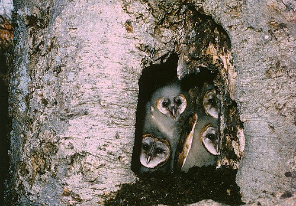

[Young Barn Owls in Tree Nest](https://flic.kr/p/66jqtt) by Hunter Desportes on Flickr

Roulin, A. and Bersier, L.F., 2007. Nestling barn owls beg more intensely in the presence of their mother than in the presence of their father. Animal Behaviour, 74(4), pp.1099-1106.

## От чего зависит призывный крик совят?

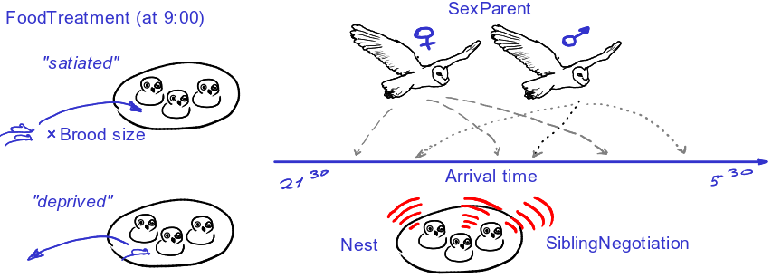

Схема эксперимента Roulin & Bersier (2007)

- `SiblingNegotiation` — число звуков в течение 15 минут до прибытия родителя
- `FoodTreatment` — сытые или голодные
- `SexParent` — пол родителя
- `ArrivalTime` — время прибытия родителя
- `Nest` — гнездо

## Знакомство с данными

```r
Owls <- read.delim("data/Roulin_Bersier_2007_Owls.csv")
str(Owls)
```

```
## 'data.frame':    599 obs. of  8 variables:
##  $ Nest              : Factor w/ 27 levels "AutavauxTV","Bochet",..: 1 1 1 1 1 1 1 1 1 1 ...
##  $ FoodTreatment     : Factor w/ 2 levels "Deprived","Satiated": 1 2 1 1 1 1 1 2 1 2 ...
##  $ SexParent         : Factor w/ 2 levels "Female","Male": 2 2 2 2 2 2 2 1 2 1 ...
##  $ ArrivalTime       : num  22.2 22.4 22.5 22.6 22.6 ...
##  $ SiblingNegotiation: int  4 0 2 2 2 2 18 4 18 0 ...
##  $ BroodSize         : int  5 5 5 5 5 5 5 5 5 5 ...
##  $ NegPerChick       : num  0.8 0 0.4 0.4 0.4 0.4 3.6 0.8 3.6 0 ...
##  $ logBroodSize      : num  1.61 1.61 1.61 1.61 1.61 ...
```

```r
# SiblingNegotiation - число криков совят - заменим на более короткое название
Owls$NCalls <- Owls$SiblingNegotiation
# Число пропущенных значений
sum(!complete.cases(Owls))
```

```
## [1] 0
```

## Есть ли выбросы?

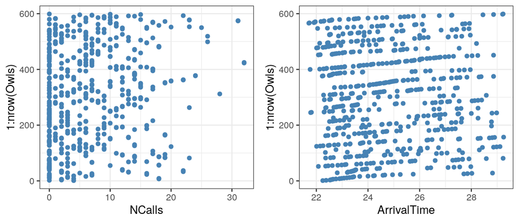

```r
library(ggplot2); library(cowplot); theme_set(theme_bw())
gg_dot <- ggplot(Owls, aes(y = 1:nrow(Owls))) +
  geom_point(colour = "steelblue")

plot_grid(gg_dot + aes(x = NCalls),
          gg_dot + aes(x = ArrivalTime), nrow = 1)
```

- Выбросов нет

## Различаются ли гнезда?

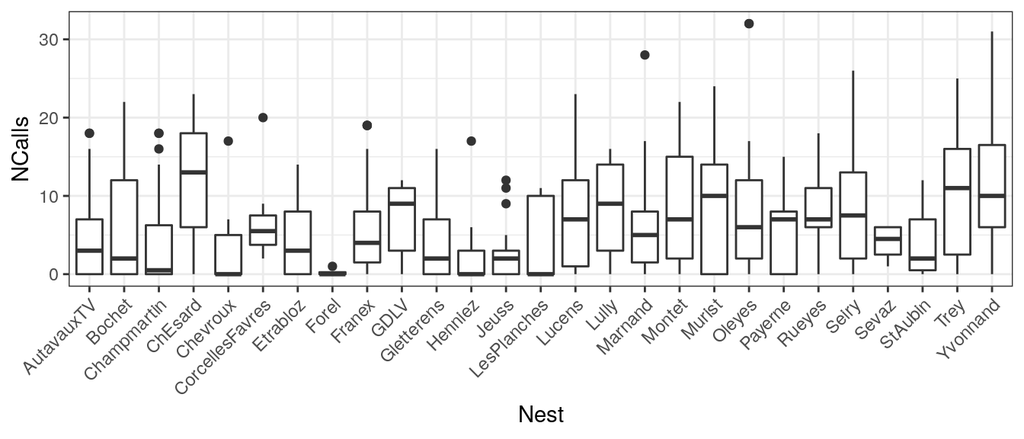

```r
ggplot(Owls, aes(x = Nest, y = NCalls)) + geom_boxplot() +
  theme(axis.text.x = element_text(angle = 45, hjust = 1))
```

- Гнезд много, они различаются. Можно и нужно учесть как случайный эффект

## Сколько наблюдений в каждом гнезде?

```r
table(Owls$Nest)
```

```
##
##      AutavauxTV          Bochet     Champmartin         ChEsard
##              28              23              30              20
##        Chevroux CorcellesFavres        Etrabloz           Forel
##              10              12              34               4
##          Franex            GDLV      Gletterens         Henniez
##              26              10              15              13
##           Jeuss     LesPlanches          Lucens           Lully
##              19              17              29              17
##         Marnand          Montet          Murist          Oleyes
##              27              41              24              52
##         Payerne          Rueyes           Seiry           Sevaz
##              25              17              26               4
##         StAubin            Trey        Yvonnand
##              23              19              34
```

- Хорошо, что наблюдений в каждом гнезде много. Только в двух по четыре - не очень.

## Отклик — счетная переменная

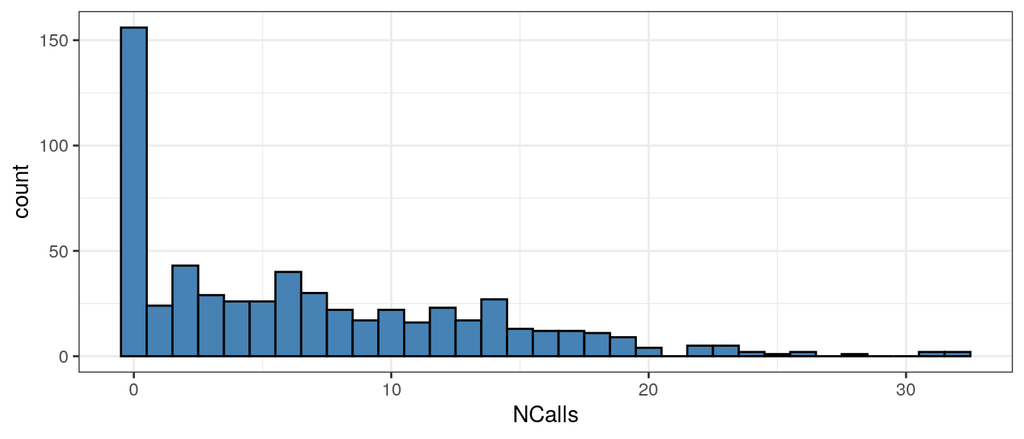

```r
ggplot(Owls, aes(x = NCalls)) +
  geom_histogram(binwidth = 1, fill = "steelblue", colour = "black")
```

Напоминает распределение Пуассона

```r
mean(Owls$NCalls == 0) # доля нулей
```

```
## [1] 0.26
```

## Какого размера выводки в гнездах?

Это нужно учесть, потому что чем больше выводок, тем больше птенцов будут разговаривать.

```r
range(Owls$BroodSize)
```

```
## [1] 1 7
```

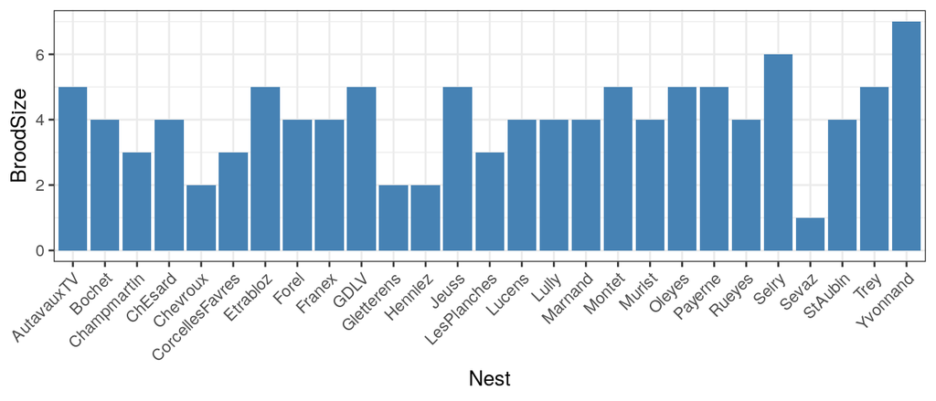

```r
ggplot(Owls, aes(x = Nest, y = BroodSize)) +
  stat_summary(geom = "bar", fun.y = mean, fill = "steelblue") +
  theme(axis.text.x = element_text(angle = 45, hjust = 1))
```

- Выводки разные. В пуассоновской glmer() это можно откорректировать при помощи offset. Сделаем offset(logBroodSize)

## Может быть есть взаимодействие?

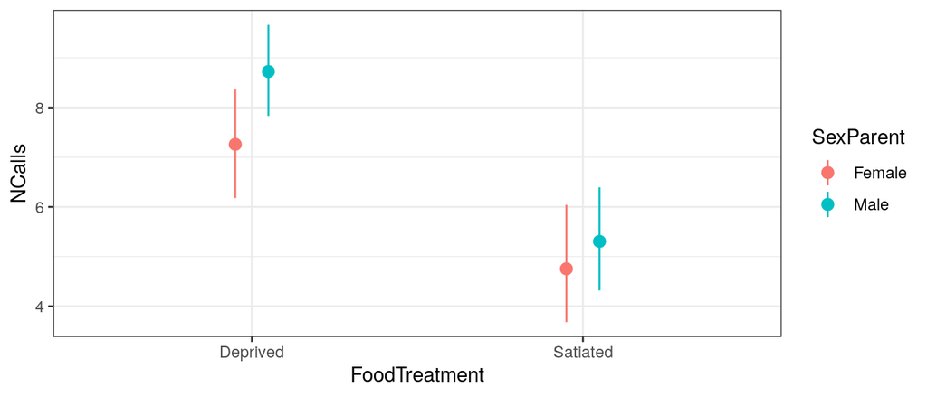

```r
ggplot(Owls) +
  stat_summary(aes(x = FoodTreatment, y = NCalls, colour = SexParent),
               fun.data = "mean_cl_boot", position = position_dodge(width = 0.2))
```

- Похоже, что может быть взаимодействие, но не понятно значимое ли.

## Когда орут птенцы?

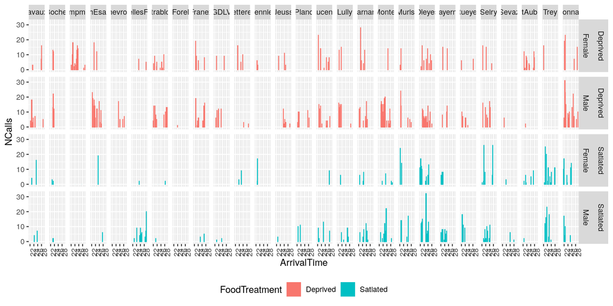

- Птенцы больше орут, если голодали прошлой ночью. И, возможно, орут у самцов (?)

## Код для графика

```r
ggplot(Owls, aes(x = ArrivalTime, y = NCalls,
                   colour = FoodTreatment, fill = FoodTreatment)) +
  geom_bar(stat = "identity") +
  facet_grid(FoodTreatment + SexParent ~ Nest) +
  theme(legend.position = "bottom",
        axis.text.x = element_text(angle = 90, hjust = 1))
```

## Коллинеарность

```r
M0 <- lm(NCalls ~ SexParent + FoodTreatment + ArrivalTime, data = Owls)
library(car)
vif(M0)
```

```
##     SexParent FoodTreatment   ArrivalTime
##        1.0036        1.0044        1.0024
```

- ок

## Смешанная линейная модель с пуассоновским распределением остатков

## Линейная модель с пуассоновским распределением остатков

- \(NCalls \sim Poisson(\mu_{ij})\) — отклик подчиняется распределению Пуассона с параметром \(\mu\)
- \(E(NCalls_{ij}) = \mu_{ij}\), \(var(NCalls_{ij}) = \mu_{ij}\)
- \(ln(\mu_{ij}) = \eta_{ij}\) — функция связи — логарифм
- \(\begin{array}{l}\eta_{ij} = \beta_0 + \beta_{1}SexParentM_{ij} + \beta_{2}FoodTreatmentS_{ij} + \beta_{3}ArrivalTime_{ij} + \\ + \beta_{4} SexParentM_{ij} FoodTreatmentS_{ij} + \beta_{5}SexParentM_{ij}ArrivalTime_{ij} + \\ + log(BroodSize_{i}) + a_{i} \end{array}\)
- \(a_{i}\sim N(0, \sigma^2_{Nest})\) — случайный эффект гнезда (intercept)
- \(i\) — гнездо
- \(j\) — наблюдение

## Подберем линейную модель с пуассоновским распределением остатков

```r
library(lme4)
M1 <- glmer(NCalls ~ SexParent * FoodTreatment +
              SexParent * ArrivalTime +
              offset(logBroodSize) + (1 | Nest),
            family = "poisson", data = Owls)
```

Смешанная модель с распределением Пуассона не сходится. Один из возможных вариантов выхода - стандартизация предикторов

## Стандартизируем непрерывные предикторы

У нас только один непрерывный предиктор

```r
Owls$ArrivalTime_std <- (Owls$ArrivalTime - mean(Owls$ArrivalTime)) /
  sd(Owls$ArrivalTime)

M1 <- glmer(NCalls ~ SexParent * FoodTreatment +
              SexParent * ArrivalTime_std +
              offset(logBroodSize) + (1 | Nest),
            family = "poisson", data = Owls)
```

Эта модель сходится

## Задание:

Проверьте модель M1 на избыточность дисперсии

## Избыточность дисперсии (Overdispersion)

Для начала разберемся, как это считать вручную

```r
R_M1 <- resid(M1, type = "pearson") # Пирсоновские остатки
N <- nrow(Owls) # Объем выборки
p <- length(fixef(M1)) + 1# Число параметров (не забудьте сл. эффект!)
df <- (N - p) # число степеней свободы
overdispersion <- sum(R_M1^2) /df  # во сколько раз var(y) > E(y)
overdispersion
```

```
## [1] 5.46
```

```r
pchisq(sum(R_M1^2), df = df, lower.tail = FALSE)
```

```
## [1] 0
```

- Избыточность дисперсии.

## Избыточность дисперсии при помощи готовых функций

```r
# ## Проверка на сверхдисперсию
# Функция для проверки наличия сверхдисперсии в модели (автор Ben Bolker)
# http://bbolker.github.io/mixedmodels-misc/glmmFAQ.html
# Код модифицирован, чтобы учесть дополнительный параметр в NegBin GLMM, подобранных MASS::glm.nb()
overdisp_fun <- function(model) {
  rdf <- df.residual(model)  # Число степеней свободы N - p
  if (any(class(model) == 'negbin')) rdf <- rdf - 1 ## учитываем k в NegBin GLMM
  rp <- residuals(model,type='pearson') # Пирсоновские остатки
  Pearson.chisq <- sum(rp^2) # Сумма квадратов остатков, подчиняется Хи-квадрат распределению
  prat <- Pearson.chisq/rdf  # Отношение суммы квадратов остатков к числу степеней свободы
  pval <- pchisq(Pearson.chisq, df=rdf, lower.tail=FALSE) # Уровень значимости
  c(chisq=Pearson.chisq,ratio=prat,rdf=rdf,p=pval)        # Вывод результатов
}

overdisp_fun(M1)
```

```
##   chisq   ratio     rdf       p
## 3232.74    5.46  592.00    0.00
```

```r
library(performance)
check_overdispersion(M1)
```

```
## # Overdispersion test
##
##        dispersion ratio =    5.461
##   Pearson's Chi-Squared = 3232.737
##                 p-value =  < 0.001
```

## Почему здесь могла быть избыточность дисперсии?

- Отскакивающие значения –> убрать
- Пропущены ковариаты или взаимодействия предикторов –> добавить
- Наличие внутригрупповых корреляций (нарушение независимости выборок) –> другие случайные эффекты?
- Нелинейная взаимосвязь между ковариатами и зависимой переменной –> GAMM
- Неверно подобрана связывающая функция –> заменить
- Количество нулей больше, чем предсказывает распределение Пуассона (Zero inflation) –> ZIP
- Просто большая дисперсия? –> NB

## График остатков

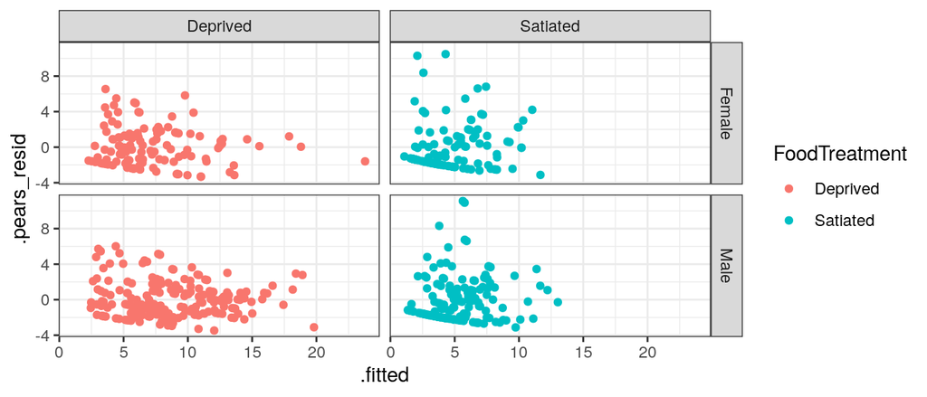

```r
M1_diag <- data.frame(Owls,
                      .fitted = predict(M1, type = "response"),
                      .pears_resid = residuals(M1, type = "pearson"))

gg_resid <- ggplot(M1_diag, aes(x = .fitted, y = .pears_resid,
                       colour = FoodTreatment)) +
  geom_point() +
  facet_grid(SexParent ~ FoodTreatment)
gg_resid
```

- Есть большие остатки

## Есть ли еще какие-то паттерны в остатках?

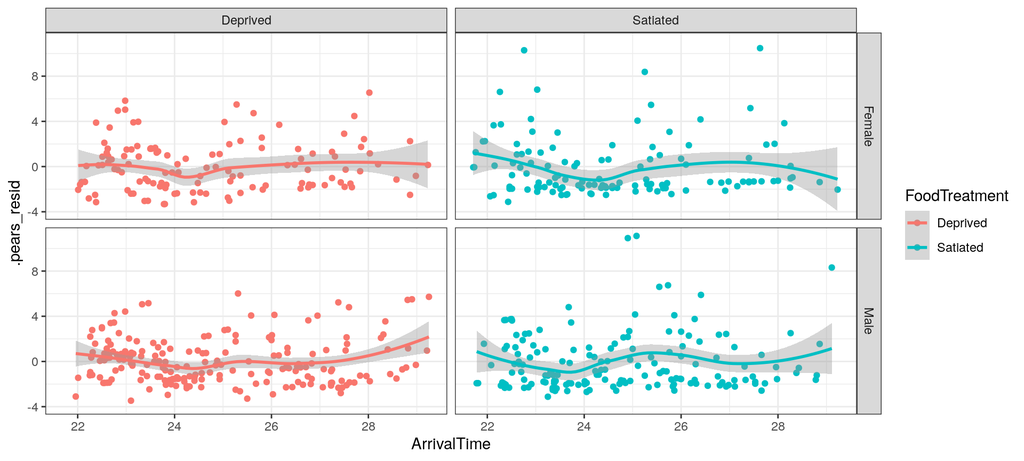

```r
gg_resid %+% aes(x = ArrivalTime) + geom_smooth(method = "loess")
```

- Есть намек на нелинейность. Возможно, нужен GAMM

## Проверяем, есть ли нелинейный паттерн в остатках

```r
library(mgcv)
nonlin1 <- gam(.pears_resid ~ s(ArrivalTime),
               data = M1_diag)
summary(nonlin1)
```

```
##
## Family: gaussian
## Link function: identity
##
## Formula:
## .pears_resid ~ s(ArrivalTime)
##
## Parametric coefficients:
##             Estimate Std. Error t value Pr(>|t|)
## (Intercept)  -0.0111     0.0920   -0.12      0.9
##
## Approximate significance of smooth terms:
##                 edf Ref.df    F   p-value
## s(ArrivalTime) 7.15    8.2 5.04 0.0000049 ***
## ---
## Signif. codes:  0 '***' 0.001 '**' 0.01 '*' 0.05 '.' 0.1 ' ' 1
##
## R-sq.(adj) =  0.0618   Deviance explained =  7.3%
## GCV = 5.1414  Scale est. = 5.0715    n = 599
```

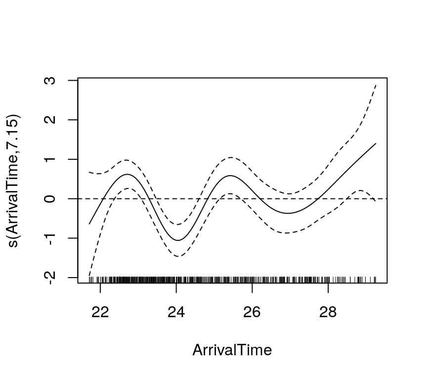

```r
plot(nonlin1)
abline(h = 0, lty = 2)
```

- Совершенно точно нужен GAMM. Но продолжим с GLMM

## Смешанная линейная модель с отрицательным биномиальным распределением остатков

## У нас была сверхдисперсия. Пробуем NB GLMM

- \(NCalls_{ij} \sim NegBin(\mu_{ij}, k)\) — отклик подчиняется отрицательному биномиальному распределению с параметрами \(\mu\) и \(k\)
- \(E(NCalls_{ij}) = \mu_{ij}\), \(var(NCalls_{ij}) = \mu_{ij} + \mu^2_{ij} / k\)
- \(ln(\mu_{ij}) = \eta_{ij}\) — функция связи — логарифм
- \(\begin{array}{l}\eta_{ij} = \beta_0 + \beta_{1}SexParentM_{ij} + \beta_{2}FoodTreatmentS_{ij} + \beta_{3}ArrivalTime_{ij} + \\ + \beta_{4} SexParentM_{ij} FoodTreatmentS_{ij} + \beta_{5}SexParentM_{ij}ArrivalTime_{ij} + \\+ log(BroodSize_{i}) + a_{i} \end{array}\)
- \(a_{i}\sim N(0, \sigma^2_{Nest})\) — случайный эффект гнезда (intercept)
- \(i\) — гнездо
- \(j\) — наблюдение

## Подберем NB GLMM

```r
M2 <- glmer.nb(NCalls ~ SexParent * FoodTreatment +
                 SexParent * ArrivalTime_std +
                 offset(logBroodSize) + (1 | Nest),
               data = Owls)
# # Если эта модель вдруг не сходится, есть обходной маневр.
# Можно попробовать заранее определить k  при помощи внутренней функции.
# В lme4 параметр k называется theta
th <- lme4:::est_theta(M1)
M2 <- update(M1, family = negative.binomial(theta=th))
```

## Задание:

Проверьте модель с отрицательным биномиальным распределением отклика

- на избыточность дисперсии
- наличие паттернов в остатках
- нелинейность паттернов в остатках

## Избыточность дисперсии (Overdispersion)

```r
R_M2 <- resid(M2, type = "pearson") # Пирсоновские остатки
N <- nrow(Owls) # Объем выборки
p <- length(fixef(M2)) + 1 + 1  # Число параметров (Не забудьте сл.эффект и k)
df <- (N - p) # число степеней свободы
overdispersion <- sum(R_M2^2) /df  # во сколько раз var(y) > E(y)
overdispersion
```

```
## [1] 0.9
```

```r
pchisq(sum(R_M2^2), df = df, lower.tail = FALSE)
```

```
## [1] 0.96
```

- Хорошо.

## Диагностика отр. биномиальной модели

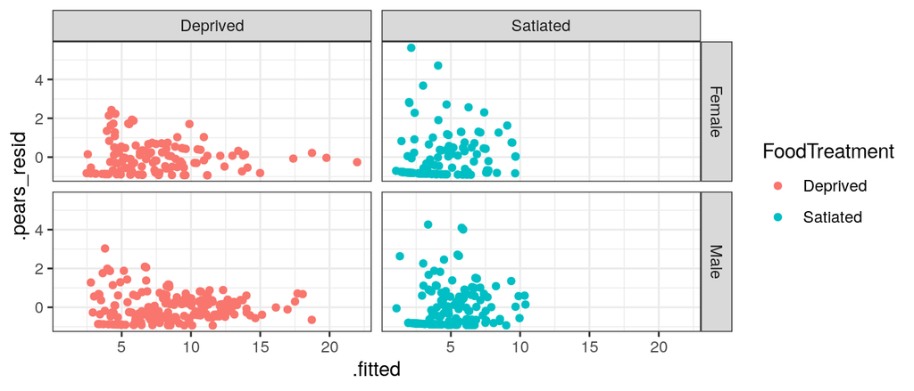

```r
M2_diag <- data.frame(Owls,
                      .fitted = predict(M2, type = "response"),
                      .pears_resid = residuals(M2, type = "pearson"))
gg_resid <- ggplot(M2_diag, aes(x = .fitted, y = .pears_resid,
                                colour = FoodTreatment)) +
  geom_point() +
  facet_grid(SexParent ~ FoodTreatment)
gg_resid
```

- Есть большие остатки.

## Есть ли еще какие-то паттерны в остатках?

Может быть паттерны в остатках исчезли от того, что мы использовали другую GLMM?

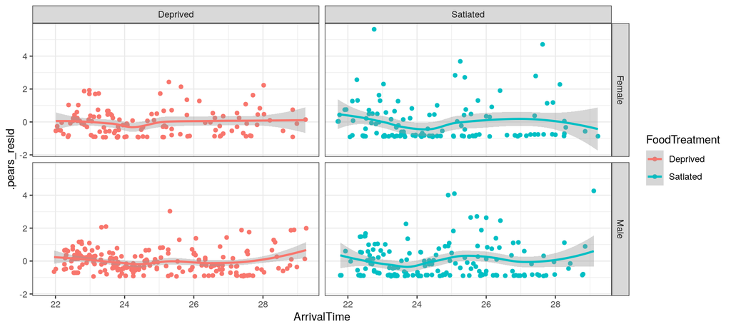

```r
gg_resid %+% aes(x = ArrivalTime) + geom_smooth(method = 'loess')
```

- Подозрительно. Возможно, нужен GAMM

## Проверяем, есть ли нелинейные паттерны

```r
nonlin2 <- gam(.pears_resid ~ s(ArrivalTime),
               data = M2_diag)
summary(nonlin2)
```

```
##
## Family: gaussian
## Link function: identity
##
## Formula:
## .pears_resid ~ s(ArrivalTime)
##
## Parametric coefficients:
##             Estimate Std. Error t value Pr(>|t|)
## (Intercept) -0.00149    0.03746   -0.04     0.97
##
## Approximate significance of smooth terms:
##                 edf Ref.df    F p-value
## s(ArrivalTime) 7.03   8.11 4.56 0.00002 ***
## ---
## Signif. codes:  0 '***' 0.001 '**' 0.01 '*' 0.05 '.' 0.1 ' ' 1
##
## R-sq.(adj) =  0.0553   Deviance explained = 6.64%
## GCV = 0.85191  Scale est. = 0.84049   n = 599
```

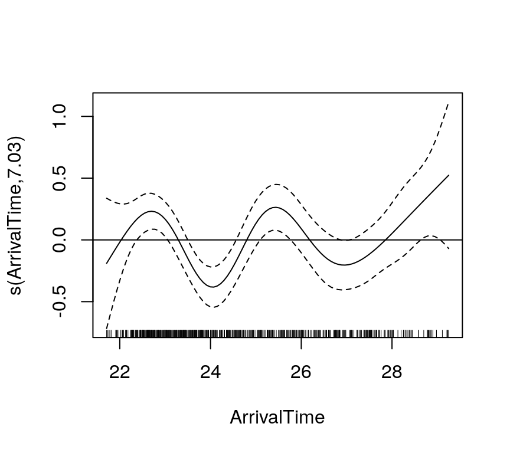

```r
plot(nonlin2)
abline(h = 0)
```

- Совершенно точно нужен GAMM

## Подбор оптимальной модели

## Подбор оптимальной модели

Все ли значимо?

```r
summary(M2)
```

```
## Generalized linear mixed model fit by maximum likelihood (Laplace
##   Approximation) [glmerMod]
##  Family: Negative Binomial(0.949)  ( log )
## Formula:
## NCalls ~ SexParent * FoodTreatment + SexParent * ArrivalTime_std +
##     offset(logBroodSize) + (1 | Nest)
##    Data: Owls
##
##      AIC      BIC   logLik deviance df.resid
##     3480     3515    -1732     3464      591
##
## Scaled residuals:
##    Min     1Q Median     3Q    Max
## -0.936 -0.799 -0.211  0.449  5.630
##
## Random effects:
##  Groups Name        Variance Std.Dev.
##  Nest   (Intercept) 0.115    0.339
## Number of obs: 599, groups:  Nest, 27
##
## Fixed effects:
##                                     Estimate Std. Error z value
## (Intercept)                           0.6586     0.1276    5.16
## SexParentMale                        -0.0130     0.1383   -0.09
## FoodTreatmentSatiated                -0.7754     0.1568   -4.95
## ArrivalTime_std                      -0.2480     0.0710   -3.49
## SexParentMale:FoodTreatmentSatiated   0.1774     0.1957    0.91
## SexParentMale:ArrivalTime_std         0.0484     0.0929    0.52
##                                       Pr(>|z|)
## (Intercept)                         0.00000025 ***
## SexParentMale                          0.92504
## FoodTreatmentSatiated               0.00000076 ***
## ArrivalTime_std                        0.00048 ***
## SexParentMale:FoodTreatmentSatiated    0.36450
## SexParentMale:ArrivalTime_std          0.60248
## ---
## Signif. codes:  0 '***' 0.001 '**' 0.01 '*' 0.05 '.' 0.1 ' ' 1
##
## Correlation of Fixed Effects:
##             (Intr) SxPrnM FdTrtS ArrvT_ SPM:FT
## SexParentMl -0.679
## FdTrtmntStt -0.595  0.549
## ArrvlTm_std  0.015 -0.009  0.048
## SxPrntM:FTS  0.443 -0.666 -0.745 -0.045
## SxPrntM:AT_ -0.005  0.004 -0.053 -0.752  0.043
```

## Задание

Попробуйте упростить модель M2

## Можно ли что-то выкинуть

```r
drop1(M2, test = "Chi")
```

```
## Single term deletions
##
## Model:
## NCalls ~ SexParent * FoodTreatment + SexParent * ArrivalTime_std +
##     offset(logBroodSize) + (1 | Nest)
##                           Df  AIC   LRT Pr(Chi)
## <none>                       3480
## SexParent:FoodTreatment    1 3479 0.824    0.36
## SexParent:ArrivalTime_std  1 3478 0.272    0.60
```

- Если выкинуть взаимодействия, модель не станет хуже

## Выкидываем одно взаимодействие

```r
M3 <- update(M2, .~.-SexParent:ArrivalTime_std)
drop1(M3, test = "Chisq")
```

```
## Single term deletions
##
## Model:
## NCalls ~ SexParent + FoodTreatment + ArrivalTime_std + (1 | Nest) +
##     SexParent:FoodTreatment + offset(logBroodSize)
##                         Df  AIC   LRT   Pr(Chi)
## <none>                     3478
## ArrivalTime_std          1 3498 21.61 0.0000033 ***
## SexParent:FoodTreatment  1 3477  0.78      0.38
## ---
## Signif. codes:  0 '***' 0.001 '**' 0.01 '*' 0.05 '.' 0.1 ' ' 1
```

- теперь можно выкинуть второе

## Выкидываем второе взаимодействие

```r
M4 <- update(M3, .~.-SexParent:FoodTreatment)
drop1(M4, test = "Chisq")
```

```
## Single term deletions
##
## Model:
## NCalls ~ SexParent + FoodTreatment + ArrivalTime_std + (1 | Nest) +
##     offset(logBroodSize)
##                 Df  AIC  LRT Pr(Chi)
## <none>             3477
## SexParent        1 3476  0.4    0.51
## FoodTreatment    1 3517 42.1 8.8e-11 ***
## ArrivalTime_std  1 3497 21.5 3.6e-06 ***
## ---
## Signif. codes:  0 '***' 0.001 '**' 0.01 '*' 0.05 '.' 0.1 ' ' 1
```

- теперь можно выкинуть пол родителя

## Финальная модель

```r
M5 <- update(M4, .~.-SexParent)
drop1(M5, test = "Chisq")
```

```
## Single term deletions
##
## Model:
## NCalls ~ FoodTreatment + ArrivalTime_std + (1 | Nest) + offset(logBroodSize)
##                 Df  AIC  LRT Pr(Chi)
## <none>             3476
## FoodTreatment    1 3517 43.0 5.5e-11 ***
## ArrivalTime_std  1 3495 21.2 4.1e-06 ***
## ---
## Signif. codes:  0 '***' 0.001 '**' 0.01 '*' 0.05 '.' 0.1 ' ' 1
```

- это финальная модель

## Второй способ подбора оптимальной модели - AIC

```r
AIC(M2, M3, M4, M5)
```

```
##    df  AIC
## M2  8 3480
## M3  7 3478
## M4  6 3477
## M5  5 3476
```

## Модель изменилась. Нужно повторить диагностику

Избыточность дисперсии (Overdispersion)

```r
R_M5 <- resid(M5, type = "pearson") # Пирсоновские остатки
N <- nrow(Owls) # Объем выборки
p <- length(fixef(M5)) + 1 + 1  # Число параметров в модели
df <- (N - p) # число степеней свободы
overdispersion <- sum(R_M5^2) /df  # во сколько раз var(y) > E(y)
overdispersion
```

```
## [1] 0.894
```

```r
pchisq(sum(R_M5^2), df = df, lower.tail = FALSE)
```

```
## [1] 0.97
```

- Хорошо.

## Диагностика отр. биномиальной модели

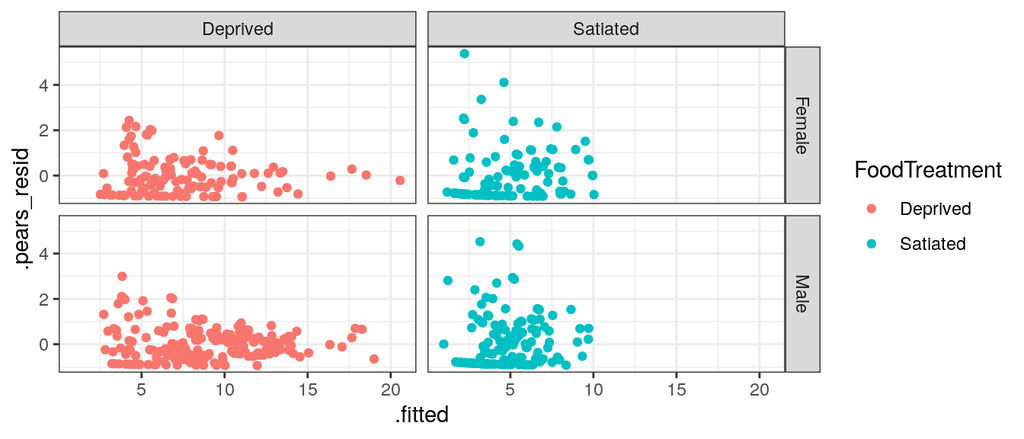

```r
M5_diag <- data.frame(Owls,
                      .fitted <- predict(M5, type = "response"),
                      .pears_resid <- residuals(M5, type = "pearson"))
gg_resid <- ggplot(M5_diag, aes(x = .fitted, y = .pears_resid,
                                colour = FoodTreatment)) +
  geom_point() +
  facet_grid(SexParent ~ FoodTreatment)
gg_resid
```

- Есть большие остатки

## Есть ли еще какие-то паттерны в остатках?

Может быть паттерны в остатках исчезли от того, что мы использовали другую GLMM?

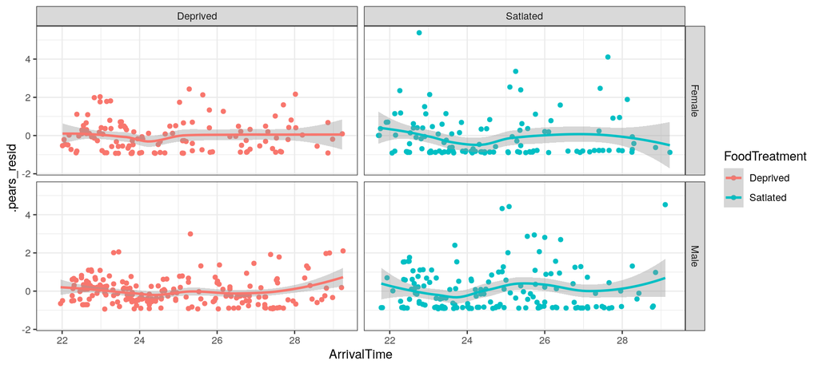

```r
gg_resid %+% aes(x = ArrivalTime) + geom_smooth(method = "loess")
```

- Подозрительно. Возможно, нужен GAMM

## Проверяем, есть ли нелинейные паттерны

```r
nonlin5 <- gam(.pears_resid ~ s(ArrivalTime), data = M5_diag)
summary(nonlin5)
```

```
##
## Family: gaussian
## Link function: identity
##
## Formula:
## .pears_resid ~ s(ArrivalTime)
##
## Parametric coefficients:
##             Estimate Std. Error t value Pr(>|t|)
## (Intercept) -0.00147    0.03740   -0.04     0.97
##
## Approximate significance of smooth terms:
##                edf Ref.df    F  p-value
## s(ArrivalTime)   7   8.08 4.61 0.000017 ***
## ---
## Signif. codes:  0 '***' 0.001 '**' 0.01 '*' 0.05 '.' 0.1 ' ' 1
##
## R-sq.(adj) =  0.0559   Deviance explained =  6.7%
## GCV = 0.84925  Scale est. = 0.83791   n = 599
```

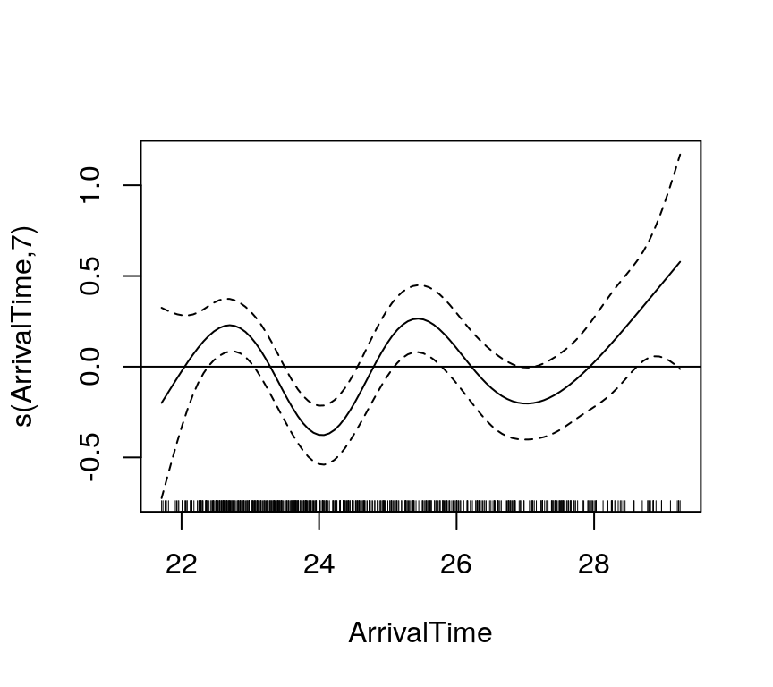

```r
plot(nonlin5)
abline(h = 0)
```

- Совершенно точно нужен GAMM
- Но мы продолжим

## Готовим данные для графика модели

```r
library(dplyr)
NewData <- Owls %>% group_by(FoodTreatment) %>%
  do(data.frame(ArrivalTime_std = seq(min(.$ArrivalTime_std),
                                       max(.$ArrivalTime_std),
                                       length = 100)))
NewData$ArrivalTime <- NewData$ArrivalTime_std * sd(Owls$ArrivalTime) +
  mean(Owls$ArrivalTime)
```

## Предсказания и ошибки

```r
# Модельная матрица
X <- model.matrix(~ FoodTreatment + ArrivalTime_std, data = NewData)
# К предсказанным значениям нужно прибавить офсет.
# Мы будем делать предсказания для среднего размера выводка.
# В масштабе функции связи
NewData$fit_eta <- X %*% fixef(M5) + log(mean(Owls$BroodSize))
NewData$SE_eta <- sqrt(diag(X %*% vcov(M5) %*% t(X)))
# В масштабе отклика
NewData$fit_mu <- exp(NewData$fit_eta)
NewData$lwr <- exp(NewData$fit_eta - 2 * NewData$SE_eta)
NewData$upr <- exp(NewData$fit_eta + 2 * NewData$SE_eta)
```

## График предсказанных значений

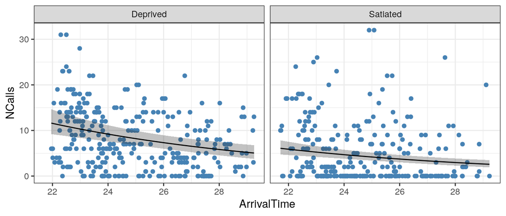

```r
ggplot() +
  geom_point(data = Owls, aes(x = ArrivalTime, y = NCalls), colour = "steelblue") +
  geom_ribbon(data = NewData, aes(x = ArrivalTime,  ymax = upr,  ymin = lwr), alpha = 0.3) +
  geom_line(data = NewData,  aes(x = ArrivalTime, y = fit_mu, group = FoodTreatment)) +
  facet_wrap(~ FoodTreatment)
```

## Take-home messages

- В случае счетных зависимых переменных (неотрицательных целочисленных величин) применяются модели, основанные на распределении Пуассона или отрицательном биномиальном распределении.
- При проверке на избыточность дисперсии таких смешанных линейных моделей, нужно учитывать дополнительные параметры: дисперсию связанную со случайными факторами, и параметр тета для отрицательного биномиального распределения
- Нелинейные паттерны в остатках иногда могут быть причиной избыточности дисперсии.

## Дополнительные ресурсы

- Crawley, M.J. (2007). The R Book (Wiley).
- Zuur, A.F., Ieno, E.N., Walker, N., Saveliev, A.A., and Smith, G.M. (2009). Mixed Effects Models and Extensions in Ecology With R (Springer).